# Springboard Foundations of Data Science Milestone Report

# Predicting the Accuracy of Credit Card Default

In this project we will attempt to identify credit card holders that are most likely to default on their loans. We will build a predictive model that measures how closely characteristics of the cardholder are related to default. Our goal is to help banks and other institutions that issue credit cards reduce their write-off rate.

## The Data

While not focused on the US market, the data set for this project looked at one response variable, default or payment of credit card debt for 30,000 Taiwanese credit card holders in October 2005.

- Client action (0 = no default, 1 = default)

The following 23 independent variables were also included.

- Credit limit available to the borrower (ranging from $10,000 to $1,000,000)
- Gender (1 = male; 2 = female)
- Education level (1 = graduate school; 2 = university; 3 = high school; 0, 4, 5, 6 = other)
- Marriage status (1 = married; 2 = single; 3 = divorce; 0 = other)
- Age in years (ranging from 21 to 79)
- History of past payment (six columns, April to September of 2005)  
  The payment scale:
  - -2 = No consumption (card holder has nothing due and didn’t access line of credit)
  - -1 = Paid in full (previous balance has been paid off)
  - 0 = Revolving credit (previous balance not fully paid off)
  - 1 = Payment delay for 1 month; 2 = payment delay for 2 months;…; 9 = payment delay for 9 months and above
- Monthly balance for past six months (April - September of 2005)
- Amount of previous monthly payment for past six months (April - September of 2005)

Data is available at the following link: [Data set](http://archive.ics.uci.edu/ml/datasets/default+of+credit+card+clients)

### Data Limitations

Two variables not included in the data set are the credit score and annual income of the borrower. Both of these variables are considered important data points for financial institutions that issue credit cards. Any conclusions from this study should take into account that these two variables were not included.

Another limitation is the study’s narrow focus on the Taiwanese credit card market. The health of the Taiwanese economy, domestic interest rates at the time of the study, and local political or cultural factors may have had an effect on the default rate that may be less relevant in other populations.

Finally, 2005 was a period where many Taiwanese financial institutions greatly expanded credit card issuance with little to no regard for the ability of borrowers to repay. In addition, card holders accumulated a higher than average level of debt during this period. This resulted in abnormally high default rates in the Taiwanese market. Credit card lending in Taiwan during this period was similar in some ways to the mortgage loan market in the US leading up to the 2008 housing crisis. Any conclusions about who fits the profile of a risky cardholder must take into account the lax lending practices of issuers during the period of this study.

### Data Wrangling

Data import and all libraries used in the analysis are below.

```r
library(readr)
library(plyr)
library(tidyr)
library(dplyr)
```

```r
library(base)
library(ggplot2)
dcc <- read_csv("~/dcc.csv")
```

The original data set was clean and comprehensive. There were no missing values. However, some column headings were originally in the form of X1, X2, X3 etc. These were renamed to the appropriate titles (Gender, Education etc). In addition, duplicate rows and the ID column were removed.

```r
# Change column names from X1, X2 etc to the value in row 2
colnames(dcc) <- dcc[1,]

# Delete row 2 to remove duplicate titles
dcc = dcc[-1,]

# Remove ID column (column #1)
dcc <- dcc[-1]

# Clean up column names
names(dcc) <- c("LimitAmt", "Gender", "Education", "Marriage", "Age", "StatusSep05", "StatusAug05"
                , "StatusJul05", "StatusJun05", "StatusMay05", "StatusApr05", "BalSep05", "BalAug05",
                "BalJul05", "BalJun05", "BalMay05", "BalApr05", "PayAmtSep05", "PayAmtAug05",
                "PayAmtJul05", "PayAmtJun05", "PayAmtMay05", "PayAmtApr05", "DefaultOct05")
```

The Education column had multiple values representing the same field. In order to remove duplicate values we merged all the duplicates together.

```r
# Convert 4,5, and 6 to 0 as they all represent "Other"
dcc$Education[dcc$Education == 4] <- 0
dcc$Education[dcc$Education == 5] <- 0
dcc$Education[dcc$Education == 6] <- 0
```

We also changed the values in each column to the corresponding category that value represents.

```r
# Change values from integer to categorical for Sex, Education, Marriage, Default columns

dcc$Gender <- factor(dcc$Gender)
levels(dcc$Gender) <- c("Male", "Female")

dcc$Education <- factor(dcc$Education)
levels(dcc$Education) <- c("Other", "GradSch", "Bachelors", "HS")

dcc$Marriage <- factor(dcc$Marriage)
levels(dcc$Marriage) <- c("Div", "Mar", "Single", "Div")

dcc$DefaultOct05 <- factor(dcc$DefaultOct05)  #NDef and Def stand for No Default and Default
levels(dcc$DefaultOct05) <- c("NDef", "Def")

# Change values from integer to categorical for payment status columns from Apr05 to May05

dcc$StatusSep05 <- factor(dcc$StatusSep05)
dcc$StatusAug05 <- factor(dcc$StatusAug05)
dcc$StatusJul05 <- factor(dcc$StatusJul05)
dcc$StatusJun05 <- factor(dcc$StatusJun05)
dcc$StatusMay05 <- factor(dcc$StatusMay05)
dcc$StatusApr05 <- factor(dcc$StatusApr05)

# Change values from -2, -1, etc to character strings

levels(dcc$StatusSep05)<- c("SepPaid", "SepNoCons", "SepRev", "Sep1MoD", "Sep2MoD", "Sep3MoD", "Sep4MoD", "Sep5MoD", "Sep6MoD", "Sep7MoD", "Sep8MoD")
levels(dcc$StatusAug05)<- c("AugPaid", "AugNoCons", "AugRev", "Aug1MoD", "Aug2MoD", "Aug3MoD", "Aug4MoD", "Aug5MoD", "Aug6MoD", "Aug7MoD", "Aug8MoD")
levels(dcc$StatusJul05)<- c("JulPaid", "JulNoCons", "JulRev", "Jul1MoD", "Jul2MoD", "Jul3MoD", "Jul4MoD", "Jul5MoD", "Jul6MoD", "Jul7MoD", "Jul8MoD")
levels(dcc$StatusJun05)<- c("JunPaid", "JunNoCons", "JunRev", "Jun1MoD", "Jun2MoD", "Jun3MoD", "Jun4MoD", "Jun5MoD", "Jun6MoD", "Jun7MoD", "Jun8MoD")
levels(dcc$StatusMay05)<- c("MayPaid", "MayNoCons", "MayRev", "May2MoD", "May3MoD", "May4MoD", "May5MoD", "May6MoD", "May7MoD", "May8MoD")
levels(dcc$StatusApr05)<- c("AprPaid", "AprNoCons", "AprRev", "Apr2MoD", "Apr3MoD", "Apr4MoD", "Apr5MoD", "Apr6MoD", "Apr7MoD", "Apr8MoD")
```

We segmented the credit limit and age of borrowers into bins in order to study how each segment effects the default rate differently. The distribution of data points with the highest concentration was split into smaller bin sizes, while those with fewer data points had wider bin sizes. For example, there were far more borrowers with lower credit limits and than those with higher credit limits.

```r
# Create bins for credit limit and age so we can group borrowers into different categories
# The LAmtCut and AgeCut variables represent where the cutoff for each bin is

dcc$LimitAmtBin <- paste(dcc$LimitAmt)
dcc$LimitAmtBin <- as.numeric(as.character(dcc$LimitAmtBin))
sapply(dcc$LimitAmtBin, class)
LAmtCut <- cut(dcc$LimitAmtBin, breaks = c(0, 10000, 25000, 50000, 100000, 250000, 500000, 1000000),
               labels = c("10KLimit", "25KLimit", "50KLimit", "100KLimit", "250KLimit", "500KLimit", "1MilLimit"))
dcc$LimitAmtBin <- LAmtCut

dcc$AgeBin <- paste(dcc$Age)
dcc$AgeBin <- as.numeric(as.character(dcc$AgeBin))
sapply(dcc$AgeBin, class)
AgeCut <- cut(dcc$AgeBin, breaks = c(20, 25, 30, 35, 40, 50, 60, 80),
              labels = c("25Y", "30Y", "35Y", "40Y", "50Y", "60Y", "80Y"))
dcc$AgeBin <- AgeCut
```

Finally, we created bins for the six monthly balance amounts and six monthly payment amounts. The code is identical to the code used to create the credit limit and age bins. Much like the Age and Credit limit bins, the bins sizes reflect the concentration of borrowers at each level.

## Feature Engineering

The goal of feature engineering was to explore the relationship between the default rate and the 23 independent variables. Our baseline for comparison is simply the percentage of total loans that default.

```r
table(dcc$DefaultOct05)/length(dcc$DefaultOct05)
```

```
##
##   NDef    Def
## 0.7788 0.2212
```

We see that across 30,000 loans, there was a default rate of 22.12%.

We then ran each independent variable versus default as well as various combinations of variables versus default. This resulted in 41 different variables (the 23 original plus the 18 combinations we created).

Each variable yielded multiple possibilities. For example, the Education variable had four different levels of education which resulted in four different default rates. The combination grouping Age and Credit Limit gave 49 different default rates as there are seven bins for both variables.

Across all of the 41 variables tested, we filtered out any results with less than 100 occurrences. This resulted in 830 different possible default rates ranging from 3% to 75%.

The variables that appeared to have the greatest influence over default were the following: Credit limit, Age, Education level, Gender, Marriage status, Payment status, and Payment amount.

## Preliminary Exploration

The goal of preliminary exploration was to take the variables we identified in feature engineering and explore them further.

Below are the graphs for those variables that appear to have some predictive power.

##### Credit Limit

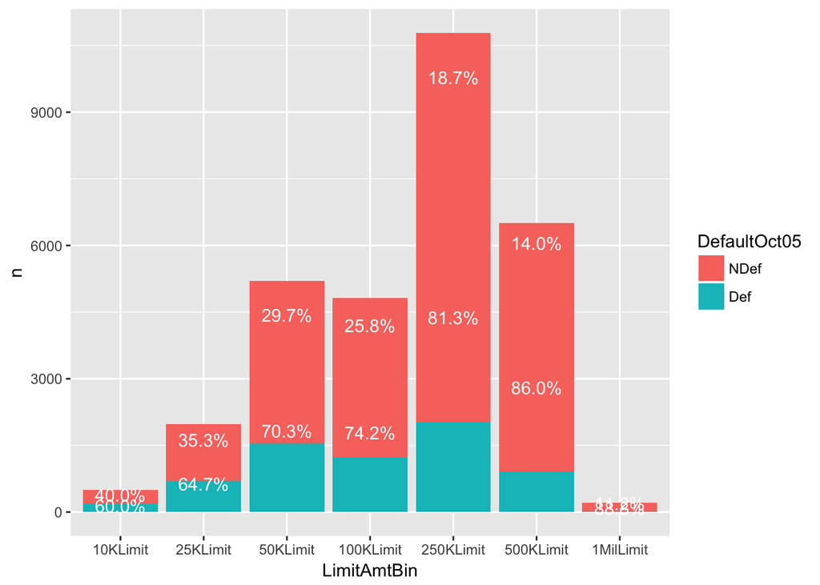

```r
summary = dcc %>% group_by(LimitAmtBin, DefaultOct05) %>% tally %>% group_by(LimitAmtBin) %>%
  mutate(pct = n/sum(n), n.pos = cumsum(n) - 0.5*n)
ggplot(summary, aes(x=LimitAmtBin, y=n, fill=DefaultOct05)) + geom_bar(stat="identity") +
  geom_text(aes(label=paste0(sprintf("%1.1f", pct*100),"%"), y=n.pos), colour="white")
```

We see that those with the lowest credit limits have the highest default rates, and those with the highest credit limits have the lowest default rates. Default rates are near 40.0% for the 10K bucket, and decline with each increasing limit bin. The largest credit limit sees a default rate of just over 11.0%.

##### Age

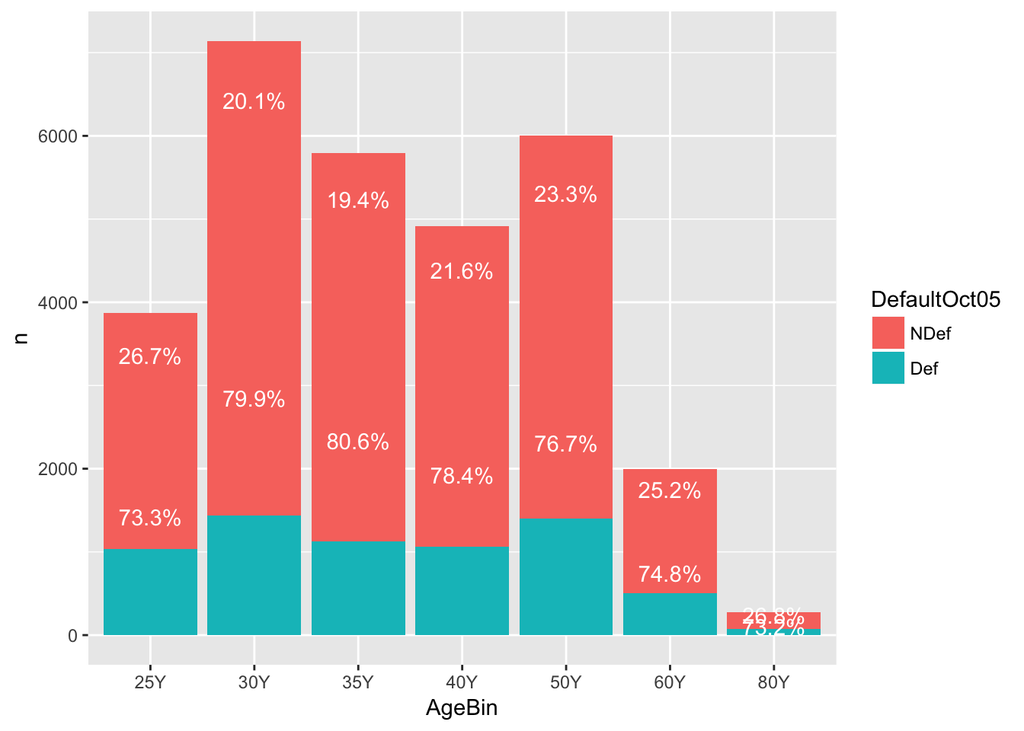

```r
summary = dcc %>% group_by(AgeBin, DefaultOct05) %>% tally %>% group_by(AgeBin) %>%
  mutate(pct = n/sum(n), n.pos = cumsum(n) - 0.5*n)
ggplot(summary, aes(x=AgeBin, y=n, fill=DefaultOct05)) + geom_bar(stat="identity") +
  geom_text(aes(label=paste0(sprintf("%1.1f", pct*100),"%"), y=n.pos), colour="white")
```

The age breakdown shows a different trend. The youngest and oldest borrowers (25 and below and those between 61 to 80) have the highest default rates, both approaching 27.0%. However, middle-age borrowers (31-35) have the lowest default rate of 19.42%. Default rates based on age have a V shape. At the extremes, loans appear to be riskier. Loans to the middle age crowd appear to be safer.

##### Education

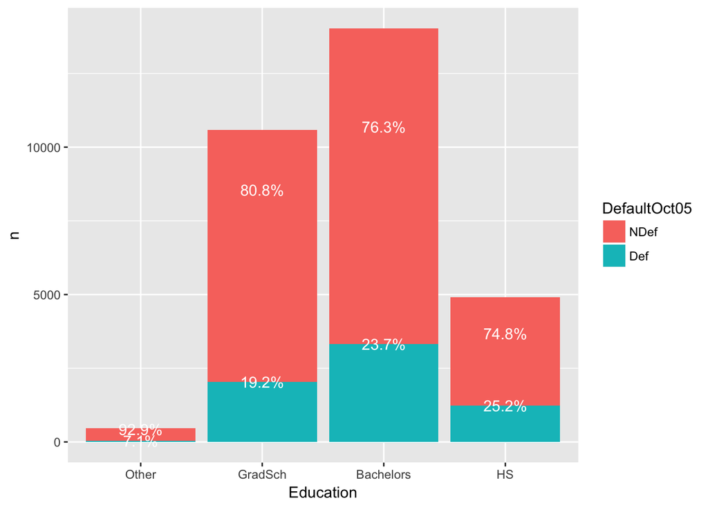

```r
summary = dcc %>% group_by(Education, DefaultOct05) %>% tally %>% group_by(Education) %>%
  mutate(pct = n/sum(n), n.pos = cumsum(n) - 0.5*n)
ggplot(summary, aes(x=Education, y=n, fill=DefaultOct05)) + geom_bar(stat="identity") +
  geom_text(aes(label=paste0(sprintf("%1.1f", pct*100),"%")), colour="white")
```

Education shows an interesting trend that intuitively makes sense. The higher the level of education, the lower the default rate. For example, those with only a high school education default over 25% of the time, while those with only a bachelors degree have a default rate of 23.73%, which is higher than our baseline, but still an improvement over high school. Finally, those with a graduate degree have the lowest default rate of 19.23%.

##### Gender

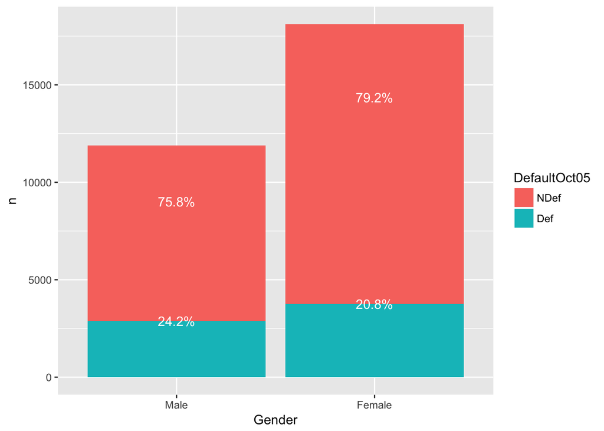

```r
summary = dcc %>% group_by(Gender, DefaultOct05) %>% tally %>% group_by(Gender) %>%
  mutate(pct = n/sum(n), n.pos = cumsum(n) - 0.5*n)
ggplot(summary, aes(x=Gender, y=n, fill=DefaultOct05)) + geom_bar(stat="identity") +
  geom_text(aes(label=paste0(sprintf("%1.1f", pct*100),"%")), colour="white")
```

##### Marriage Status

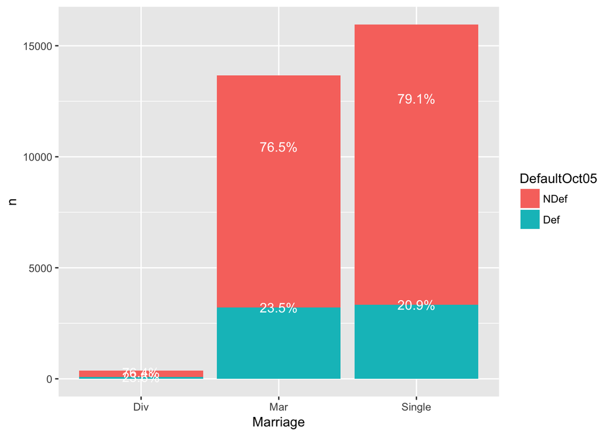

```r
summary = dcc %>% group_by(Marriage, DefaultOct05) %>% tally %>% group_by(Marriage) %>%
  mutate(pct = n/sum(n), n.pos = cumsum(n) - 0.5*n)
ggplot(summary, aes(x=Marriage, y=n, fill=DefaultOct05)) + geom_bar(stat="identity") +
  geom_text(aes(label=paste0(sprintf("%1.1f", pct*100),"%")), colour="white")
```

Marriage status provides a mixed picture. Both married and divorced borrowers default around 23.5% of the time while single borrowers who haven’t been married default 20.92% of the time.

##### Monthly Payment Status

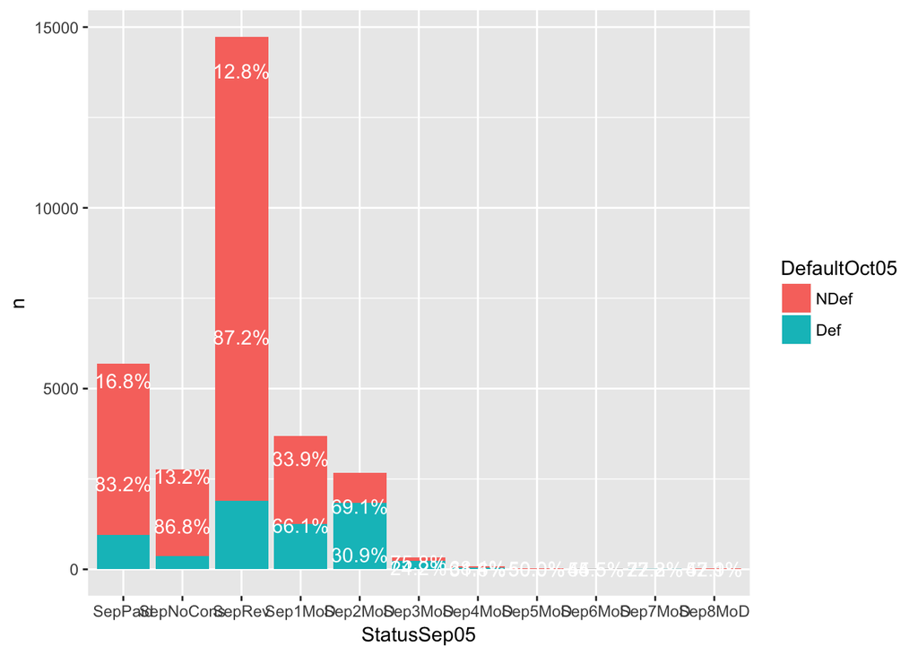

```r
summary = dcc %>% group_by(StatusSep05, DefaultOct05) %>% tally %>% group_by(StatusSep05) %>%
  mutate(pct = n/sum(n), n.pos = cumsum(n) - 0.5*n)
ggplot(summary, aes(x=StatusSep05, y=n, fill=DefaultOct05)) + geom_bar(stat="identity") +
  geom_text(aes(label=paste0(sprintf("%1.1f", pct*100),"%"), y=n.pos), colour="white")
```

Only September is shown since all six months have very similar default rates for each payment status. Regardless of month, the payment status shows a much lower default rate than the baseline for those that fall into the No Consumption, Paid in full or Revolving bins. Loans that are two or more months behind see default rates that are 50% or higher regardless of what month they are behind. We see that there isn’t much middle ground when it comes to payment status. If a cardholder is behind they are much more likely to default compared to the baseline. If they are on time, they are much less likely to default compared to the baseline.

##### Monthly Payment Amount

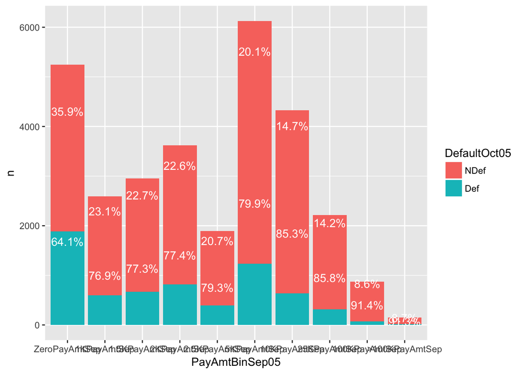

```r
summary = dcc %>% group_by(PayAmtBinSep05, DefaultOct05) %>% tally %>% group_by(PayAmtBinSep05) %>%
  mutate(pct = n/sum(n), n.pos = cumsum(n) - 0.5*n)
ggplot(summary, aes(x=PayAmtBinSep05, y=n, fill=DefaultOct05)) + geom_bar(stat="identity") +
  geom_text(aes(label=paste0(sprintf("%1.1f", pct*100),"%"), y=n.pos), colour="white")
```

Only September is shown since all six months have very similar default rates for each payment amount. We see a very clear trend with the payment amount variables. The lower the payment, the higher the default rate. This is true across all six months. As payment amounts reached the 100K and >100K amounts, default rates hovered around 8%, well below the baseline. Clearly the higher the monthly payment amount, the lower the default rate.

## Next Steps

Our original goal was to build a predictive model that can identify the variables that have the most influence over default. Our goal has not changed. Now that we’ve identified a group of variables that appear to have predictive power we will test out our assumption with a predictive model.